# `acdx`: Quick Tutorial

This is an example that illustrate a typical workflow in `acdx` using a publicly available dataset GSE144735 (Lee *et al.* 2020).

All codes are to be run inside R.

# Installation

One-time setup:

```r
library(devtools)
install_github("pwirapati/acdx")
```

This requires R with a C compiler ([Xcode](https://developer.apple.com/xcode/downloads/) for Mac, [RTools](https://cran.r-project.org/bin/windows/Rtools/) for windows).

Check by loading the package:

```r
library(acdx)
```

# Data preparation

Download the raw counts and annotations of GSE144735 from GEO into the current R working directory. These two files will take up ~55Mb of file space and bandwidth.

```r
  ## downloads large files from GEO
  baseurl <- "ftp://ftp.ncbi.nlm.nih.gov/geo/series/"
  gsesuppl <- "GSE144nnn/GSE144735/suppl/"
  download.file(paste0(baseurl,gsesuppl,
    "GSE144735_processed_KUL3_CRC_10X_annotation.txt.gz"),
    "KUL3_annotation.txt.gz")
  download.file(paste0(baseurl,gsesuppl,
    "GSE144735_processed_KUL3_CRC_10X_raw_UMI_count_matrix.txt.gz"),
    "KUL3_rawUMI.txt.gz")
```

(Alternatively, the download can be done using by a web browser to visit the relevant GEO pages. They are provided as supplementary data at the bottom of the page.)

For brevity, we will refer to this dataset as `KUL3` (KU Leuven 3’ protocol) to distinguish it from similar dataset in Lee *et al.* (2020). Various R objects derived from this dataset will have the stem `"KUL3"` in their names. (This is just a convention for convenience.)

Check if the files are in current working directory:

```r
list.files()
```

# Cell aggregation

Load the package (if not already):

```r
library(acdx)
```

Read the cell annotation data:

```r
a <- read.delim("KUL3_annotation.txt.gz")
```

Examine the content briefly:

```r
str(a)
head(a)
```

The aggregates are defined by a combination of sample and cell types identifiers.

In this example, we will use the columns `Sample` and `Cell_type`.

> There is no particular reason for this choice aside from having small, reasonable example. You can use the `Cell_subtype` columns (with more categories), or new cell type labels from your own analysis.

Perform the aggregation (can take few minutes):

```r
KUL3 <- greg("KUL3_rawUMI.txt.gz",a$Sample, a$Cell_type )
```

On completion you should see `"processed: 33694 genes"`.

> Notes:
> 1. If the raw counts has been loaded as a sparse matrix object (`dgCMatrix` format commonly used by various single-cell packages) or even as dense R matrix, you can replace the file name above with the object name. `acdx` is not aware of higher-level structure used by various other pipelines, so you have to locate the object part that has raw counts in `dgCMatrix` format, such as using `str()`.
> 2. Make sure the barcode IDs of the sample and cell type annotation vectors are in the same order as those of the raw counts matrix. In this example, the first line (column header) of the tab-delimited raw counts matches the row names of the cell annotation file. If the annotation doesn’t match the expression data exactly, but have common identifiers (such as concatenated sample and cell barcodes), use the option `cell_names=` to supply the cell names corresponding to the annotations (See the online manual for `greg`).

Examine the content of the aggregate object:

```r
str(KUL3)
```

It has two matrices, `KUL3$N` (small) and `KUL3$y` (large).

You can print the small one:

```r
KUL3$N
```

which contains the cell counts of every sample and cell type combination.

The much larger `KUL3$y` object is a four-dimensional array of (mean,SE<sup>2</sup>) x samples x genes x celltypes. To take a peek of the first two entries of each dimension:

```r
KUL3$y[,1:2,1:2,1:2]
```

`u` and `v` are mean and SE<sup>2</sup> of each sample-gene-celltype combination.

A more interesting example is the mean raw counts of highly expressed gene:

```r
KUL3$y[1,,"MALAT1",]
```

It is more convenient to see them visually:

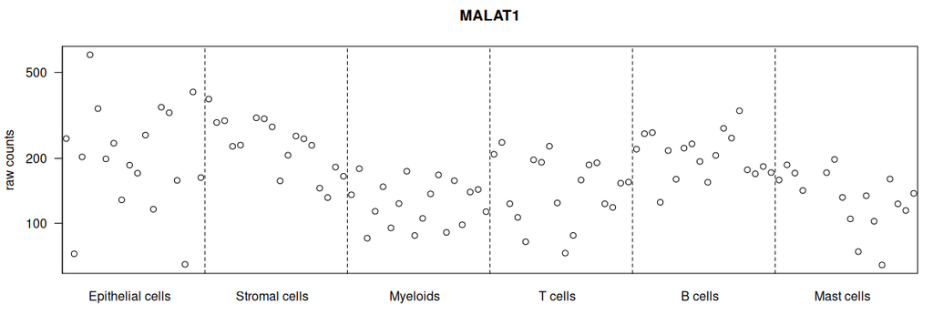

```r
acgplot(KUL3,"MALAT1")
```

# Sample Annotation Preparation

There are other information about the samples that we would like to use. In this example, it is the column `Class` of the annotation table which contains information about the tissue type:

```
table(a$Sample,a$Class)
```

They need to be reduced to a table with sample-level information (with the same sample order as used in the aggregate).

We can add them to the `KUL3` aggregate object.

```r
KUL3$a <- data.frame(row.names=rownames(KUL3$N))
KUL3$a$Class <- a[match(rownames(KUL3$a),a$Sample),"Class"]

KUL3$a
```

Suppose we don’t want to distinguish `Border` and `Tumor`. We can derive another variable.

```r
KUL3$a$tissue <- sub("Border","Tumor",KUL3$a$Class)
KUL3$a$Class <- sub("Tumor","Core",KUL3$a$Class) # rename the original
names(KUL3$a)[1] <- "region"          # change the column name

KUL3$a
```

These can be used to annotate the plot:

```r
acgplot(KUL3,sample_tags=KUL3$a$region, "EPCAM")
acgplot(KUL3,sample_tags=KUL3$a[,c("region","tissue")], "EPCAM")

mycolor <- c(Normal="green4",Border="orange",Tumor="red",Core="red2")
acgplot(KUL3,sample_tags=KUL3$a$tissue,
  col.dot=mycolor[KUL3$a$tissue], pch=20,cex=2,"EPCAM")
```

# Fit regression models

First we need to define a design matrix. There are many such matrices depending on the questions, and choice of parameterization (dummy coding). This can be a complex subject with various tools (similar to other differential expression or regression software).

For a quick example, we will use one with two columns corresponding to `Normal` and `Tumor`.

```r
KUL3$X1 <- cbind( Normal=ifelse(KUL3$a$tissue=="Normal",1,0),
                  Tumor=ifelse(KUL3$a$tissue=="Tumor",1,0))

KUL3$X1
```

It’s important to name the columns to allow reference to them later.

We can store the matrix anywhere, but it’s convenient to keep it inside the `KUL3` object. The number `1` after `X` is just to keep track in case we have many other design matrices. More descriptive names can be used.

> Note: This parameterization has no intercept, but it is convenient because the parameters correspond to average expression within the groups. The same fit can be achieved with an intercept (all `1`’s) and a contrast (e.g., Tumor is `1`, Normal is `-1`). The choice depends on what question we want to address later.

Now we fit `X1` to the data, separately for each gene in each cell type, and repeat them in 100 bootstraps (including the original sampling as the first instance).

This will take some time to run (92 seconds in a laptop with 4-core CPU i7-6700HQ) and will produce an R object with ~800Mb of size. Test first with smaller value of `n_boot` (the default is one). `verbose=1` print a hash mark for every bootstrap, to get an idea about the progression.

```
system.time( KUL3$fit1 <- acdx( KUL3, KUL3$X1, n_boot=100, verbose=1) )

object.size(KUL3$fit1)
```

The size is proportional to the number of bootstraps. We keep them in memory because they are re-usable for answering different questions.

# Querying the fitted model for specific questions

First we need to know what combinations of regression coefficients and cell types are available.

```r
questmm(KUL3$fit1$beta,showcomb=T)
```

```
      [,1]
 [1,] "Normal,Epithelial cells"
 [2,] "Tumor,Epithelial cells"
 [3,] "Normal,Stromal cells"
 [4,] "Tumor,Stromal cells"
 [5,] "Normal,Myeloids"
 [6,] "Tumor,Myeloids"
 [7,] "Normal,T cells"
 [8,] "Tumor,T cells"
 [9,] "Normal,B cells"
[10,] "Tumor,B cells"
[11,] "Normal,Mast cells"
[12,] "Tumor,Mast cells"
```

These are string labels that will be matched using regular expression.

Suppose we want to find genes that have high expression in tumor epithelial cells, but low elsewhere, we can run:

```r
top( questmm(KUL3$fit1$beta, H=c("Tu.*,Epi")), n=20)
```

This shows the top-20 genes that are high in tumor epithelial and (by default) low elsewhere. The argument to `H=` (high group) is a set of regular expression that matches the labels shown with the `showcomb=T` above.

```
                theta     SE       T PCER FWER FDP
LEMD1          3.1592 0.1845 17.1237 0.01 0.01   0
KRT23          4.3027 0.2646 16.2581 0.01 0.01   0
SFTA2          3.2936 0.2076 15.8623 0.01 0.01   0
DKK4           3.5843 0.2821 12.7054 0.01 0.01   0
KRT80          3.1890 0.2578 12.3722 0.01 0.01   0
KLK6           3.5070 0.2931 11.9653 0.01 0.01   0
ZIC5           3.5364 0.3115 11.3523 0.01 0.01   0
RP11-350J20.12 3.9848 0.3573 11.1526 0.01 0.01   0
ETV4           2.7299 0.2544 10.7288 0.01 0.01   0
CDH3           2.2521 0.2194 10.2656 0.01 0.01   0
GRIN2D         2.1802 0.2177 10.0159 0.01 0.01   0
AC016735.2     3.0791 0.3115  9.8857 0.01 0.01   0
SULT2B1        3.1941 0.3251  9.8261 0.01 0.01   0
MET            1.2285 0.1263  9.7280 0.01 0.01   0
SLC6A20        3.3821 0.3508  9.6410 0.01 0.01   0
BLACAT1        2.8773 0.3001  9.5874 0.01 0.01   0
FOXD1          2.7582 0.2918  9.4510 0.01 0.01   0
S100A2         2.4202 0.2596  9.3229 0.01 0.01   0
STRIP2         1.8833 0.2036  9.2479 0.01 0.01   0
SH3PXD2A-AS1   3.0272 0.3282  9.2231 0.01 0.01   0
```

To check the genes individually, for example LEMD1 at the top one:

```
acgplot( KUL3, sample_tags=KUL3$a[,c("region","tissue")], "LEMD1")
```

Try plotting some other genes in the list.

If we want top 5 genes high in T cells (regardless of tumor or normal):

```r
top( questmm(KUL3$fit1$beta, H=c(".*,T cells")),n=5)
```

```
       theta     SE       T PCER FWER FDP
CD3E  3.7961 0.1784 21.2784 0.01 0.01   0
CD3D  3.9376 0.2006 19.6255 0.01 0.01   0
CD3G  3.8036 0.2057 18.4930 0.01 0.01   0
GZMA  3.8928 0.2290 17.0018 0.01 0.01   0
TRBC1 3.9757 0.2548 15.6003 0.01 0.01   0
```

The pattern can be more complex. For example, if we want genes that are high in tumor of both epithelial and stroma, low elsewhere, but indifferent about whether it should be low or high in normal stroma:

```r
top(
  questmm(KUL3$fit1$beta,
  H=c("Tum.*,Epi","Tum.*,Stroma"),N=c("Nor.*,Str")))
```

> Notes:
> 1. The pattern are specified as regular expressions to `H=` (high) , `L=` (low) and `N=` (neutral). The default is `L`, but can be change by `default="H"` or `default="N"`.The ranking of the genes are based on *`min(coef_in_H)-max(coefs_in_L)`*. Coefficients in `N` are ignored.
> 2. We can assign the output of `questmm` to a named object of repeated invocation of `top` is needed. A useful option to `top` (in addition to `n=` for the number top ranking genes) is `sort.by=`.

To get the gene names of those with FWER $\le$ 0.05 (this is a multiple-testing corrected bootstrap p-value):

```r
mygenes <- rownames(
  subset(
    top( questmm(KUL3$fit1$beta,
      H=c("Tum.*,Epi","Tum.*,Stroma"),N=c("Nor.*,Str"))),
    FWER <= 0.05))

mygenes
```

To make a pdf file with plots for all these gene, with 6 genes per page:

```
pdf(file="myplot.pdf",width=8,height=12,pointsize=8)
par(mfrow=c(6,1),cex.axis=1.2,cex.lab=1.2,mar=c(8,5,3,3))
for(i in mygenes)
  acgplot(KUL3,sample_tags=KUL3$a$region,
  col.dot=mycolor[KUL3$a$region],pch=20,cex=2,i)
dev.off()
```

(Most of these tricks are basic R graphics.)

# Exercise

Repeat for the data set SMC (GSE132465), or SMC Lung adenocarcinoma (GSE131907) from Kim *et al.* (2020).

Tips: Google search ‘GSE132465’, click on GEO accession viewer (should be on top of the hit list), and scroll down to the bottom of the page to get the files. Note that this is a larger dataset than KUL3.

# Reference

Kim N, Kim HK, Lee K, Hong Y, Cho JH, Choi JW, Lee J-I, Suh Y-L, Ku BM, Eum HH, Choi S, Choi Y-L, Joung J-G, Park W-Y, Jung HA, Sun J-M, Lee S-H, Ahn JS, Park K, Ahn M-J, Lee H-O (2020) Single-cell RNA sequencing demonstrates the molecular and cellular reprogramming of metastatic lung adenocarcinoma. *Nat Commun* **11**(1): 2285. [PMID:32385277]

Lee H-O, Hong Y, Etlioglu HE, Cho YB, Pomella V, Van den Bosch B, Vanhecke J, Verbandt S, Hong H, Min J-W, Kim N, Eum HH, Qian J, Boeckx B, Lambrechts D, Tsantoulis P, De Hertogh G, Chung W, Lee T, An M, Shin H-T, Joung J-G, Jung M-H, Ko G, Wirapati P, Kim SH, Kim HC, Yun SH, Tan IBH, Ranjan B, Lee WY, Kim T-Y, Choi JK, Kim Y-J, Prabhakar S, Tejpar S, Park W-Y (2020) Lineage-dependent gene expression programs influence the immune landscape of colorectal cancer. *Nat Genet* **52**(6): 594–603. [PMID:32451460]